# Dimension Reduction

2022-11-29

## Dimension reduction

- A typical machine learning challenge will include a large number of predictors, which makes visualization somewhat challenging.
- We have shown methods for visualizing univariate and paired data, but plots that reveal relationships between many variables are more complicated in higher dimensions.
- For example, to compare each of the 784 features in our predicting digits example, we would have to create, for example, 306,936 scatterplots.

## Dimension reduction

- Creating one single scatter-plot of the data is impossible due to the high dimensionality.
- Here we describe powerful techniques useful for exploratory data analysis, among other things, generally referred to as *dimension reduction*.
- The general idea is to reduce the dimension of the dataset while preserving important characteristics, such as the distance between features or observations.
- With fewer dimensions, visualization then becomes more feasible.

## Dimension reduction

- The technique behind it all, the singular value decomposition, is also useful in other contexts.
- Principal component analysis (PCA) is the approach we will be showing.
- Before applying PCA to high-dimensional datasets, we will motivate the ideas behind with a simple example.

## Preserving distance

- We consider an example with twin heights.
- Some pairs are adults, the others are children.
- Here we simulate 100 two-dimensional points that represent the number of standard deviations each individual is from the mean height.
- Each point is a pair of twins.
- We use the `mvrnorm` function from the **MASS** package to simulate bivariate normal data.

## Preserving distance

```r
set.seed(1988)
library(MASS)
n <- 100
Sigma <- matrix(c(9, 9 * 0.9, 9 * 0.92, 9 * 1), 2, 2)
x <- rbind(mvrnorm(n / 2, c(69, 69), Sigma),
           mvrnorm(n / 2, c(55, 55), Sigma))
```

- A scatterplot quickly reveals that the correlation is high and that there are two groups of twins, the adults (upper right points) and the children (lower left points):

## Preserving distance

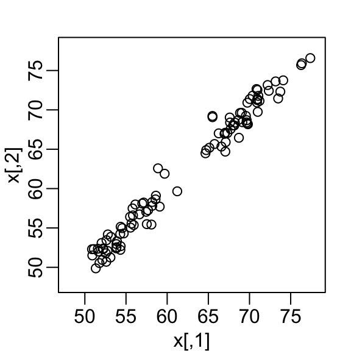

## Preserving distance

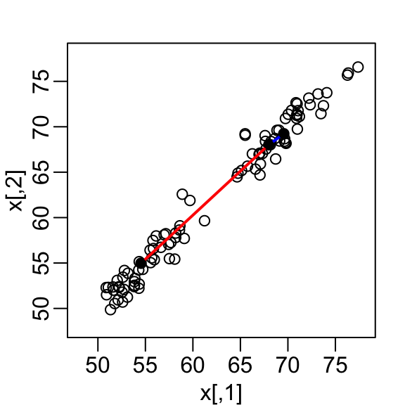

## Preserving distance

- Our features are \(N\) two-dimensional points, the two heights, and, for illustrative purposes, we will act as if visualizing two dimensions is too challenging.
- We therefore want to reduce the dimensions from two to one, but still be able to understand important characteristics of the data, for example that the observations cluster into two groups: adults and children.
- Let’s consider a specific challenge: we want a one-dimensional summary of our predictors from which we can approximate the distance between any two observations.

## Preserving distance

```r
d <- dist(x)
as.matrix(d)[1, 2]
```

```
#> [1] 1.98
```

```r
as.matrix(d)[2, 51]
```

```
#> [1] 18.7
```

- This distance is based on two dimensions and we need a distance approximation based on just one.

## Preserving distance

- Let’s start with the naive approach of simply removing one of the two dimensions.
- Let’s compare the actual distances to the distance computed with just the first dimension:

```r
z <- x[,1]
```

## Preserving distance

- Here are the approximate distances versus the original distances:

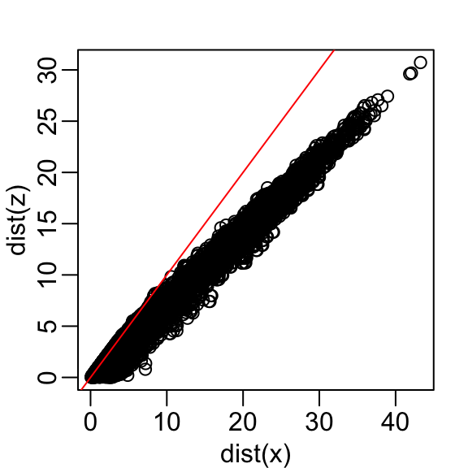

## Preserving distance

- The plot looks about the same if we use the second dimension.
- We obtain a general underestimation.
- This is to be expected because we are adding more positive quantities in the distance calculation as we increase the number of dimensions.

## Preserving distance

- If instead we use an average, like this.

\[\sqrt{ \frac{1}{2} \sum_{j=1}^2 (X_{1,j}-X_{2,j})^2 },\]

- then the underestimation goes away.
- We divide the distance by \(\sqrt{2}\) to achieve the correction.

## Preserving distance

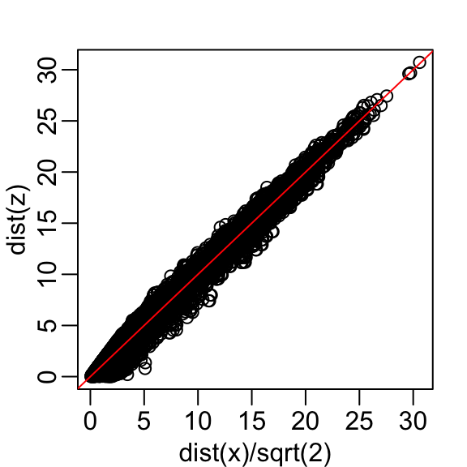

## Preserving distance

- This actually works pretty well and we get a typical difference of:

```r
sd(dist(x) - dist(z)*sqrt(2))
```

```
#> [1] 1.21
```

- Now, can we pick a one-dimensional summary that makes this approximation even better?
- If we look back at the previous scatterplot and visualize a line between any pair of points, the length of this line is the distance between the two points.
- These lines tend to go along the direction of the diagonal.

## Preserving distance

- Notice that if we instead plot the difference versus the average:

```r
z  <- cbind((x[,2] + x[,1])/2,  x[,2] - x[,1])
```

- we can see how the distance between points is mostly explained by the first dimension: the average.

## Preserving distance

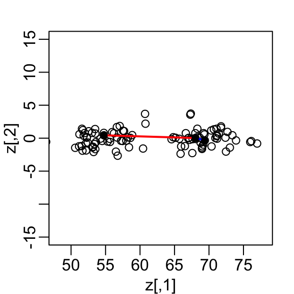

## Preserving distance

- This means that we can ignore the second dimension and not lose too much information.
- If the line is completely flat, we lose no information at all.

## Preserving distance

- Using the first dimension of this transformed matrix we obtain an even better approximation:

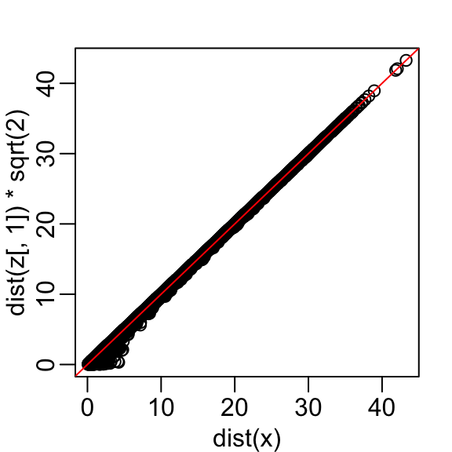

## Preserving distance

```r
sd(dist(x) - dist(z[,1])*sqrt(2))
```

```
#> [1] 0.315
```

- Later we learn that `z[,1]` is the first principal component of the matrix `x`.

## Linear transformations

- Note that each row of \(X\) was transformed using a linear transformation.
- For any row \(i\), the first entry was:

\[Z_{i,1} = a_{1,1} X_{i,1} + a_{2,1} X_{i,2}\]

- with \(a_{1,1} = 0.5\) and \(a_{2,1} = 0.5\).
- The second entry was also a linear transformation:

\[Z_{i,2} = a_{1,2} X_{i,1} + a_{2,2} X_{i,2}\]

- with \(a_{1,2} = 1\) and \(a_{2,2} = -1\).

## Linear transformations

- We can also use linear transformation to get \(X\) back from \(Z\):

\[X_{i,1} = b_{1,1} Z_{i,1} + b_{2,1} Z_{i,2}\]

- with \(b_{1,2} = 1\) and \(b_{2,1} = 0.5\) and.

\[X_{i,2} = b_{2,1} Z_{i,1} + b_{2,2} Z_{i,2}\]

- with \(b_{2,1} = 1\) and \(a_{1,2} = -0.5\).

## Linear transformations

- We can write the operation we just performed like this:

\[ Z = X A \mbox{ with } A = \, \begin{pmatrix} 1/2&1\\ 1/2&-1\\ \end{pmatrix}. \]

## Linear transformations

- And that we can transform back by simply multiplying by \(A^{-1}\) as follows:

\[ X = Z A^{-1} \mbox{ with } A^{-1} = \, \begin{pmatrix} 1&1\\ 1/2&-1/2\\ \end{pmatrix}. \]

## Linear transformations

- Dimension reduction can often be described as applying a transformation \(A\) to a matrix \(X\) with many columns that *moves* the information contained in \(X\) to the first few columns of \(Z=AX\), then keeping just these few informative columns, thus reducing the dimension of the vectors contained in the rows.

## Orthogonal transformations

- Note that we divided the above by \(\sqrt{2}\) to account for the differences in dimensions when comparing a 2 dimension distance to a 1 dimension distance.
- We can actually guarantee that the distance scales remain the same if we re-scale the columns of \(A\) to assure that the sum of squares is 1.

\[a_{1,1}^2 + a_{2,1}^2 = 1\mbox{ and } a_{1,2}^2 + a_{2,2}^2=1,\]

- and that the correlation of the columns is 0:

\[ a_{1,1} a_{1,2} + a_{2,1} a_{2,2} = 0. \]

## Orthogonal transformations

- Remember that if the columns are centered to have average 0, then the sum of squares is equivalent to the variance or standard deviation squared.
- In our example, to achieve orthogonality, we multiply the first set of coefficients (first column of \(A\)) by \(\sqrt{2}\) and the second by \(1/\sqrt{2}\), then we get the same exact distance if we use both dimensions:

```r
z[,1] <- (x[,1] + x[,2]) / sqrt(2)
z[,2] <- (x[,2] - x[,1]) / sqrt(2)
```

## Orthogonal transformations

- This gives us a transformation that preserves the distance between any two points:

```r
max(dist(z) - dist(x))
```

```
#> [1] 3.24e-14
```

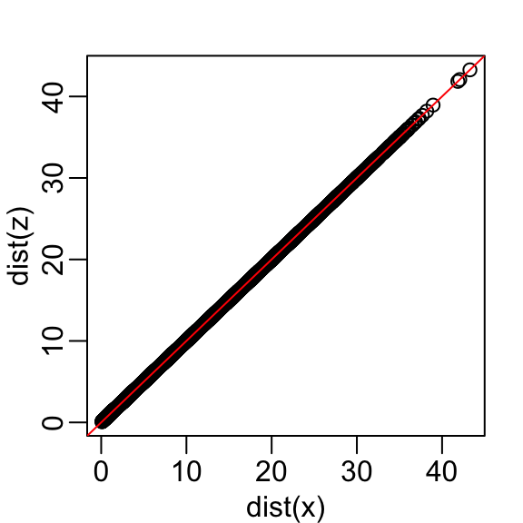

## Orthogonal transformations

- and an improved approximation if we use just the first dimension:

```r
sd(dist(x) - dist(z[,1]))
```

```
#> [1] 0.315
```

- In this case \(Z\) is called an orthogonal rotation of \(X\): it preserves the distances between rows.
- Note that by using the transformation above we can summarize the distance between any two pairs of twins with just one dimension.

## Orthogonal transformations

- For example, one-dimensional data exploration of the first dimension of \(Z\) clearly shows that there are two groups, adults and children:

```r
library(tidyverse)
qplot(z[,1], bins = 20, color = I("black"))
```

## Orthogonal transformations

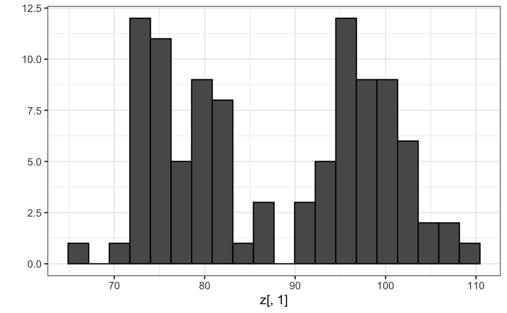

## Orthogonal transformations

- We successfully reduced the number of dimensions from two to one with very little loss of information.
- The reason we were able to do this is because the columns of \(X\) were very correlated:

```r
cor(x[,1], x[,2])
```

```
#> [1] 0.988
```

- and the transformation produced uncorrelated columns with “independent” information in each column:

```r
cor(z[,1], z[,2])
```

```
#> [1] 0.0876
```

## Orthogonal transformations

- One way this insight may be useful in a machine learning application is that we can reduce the complexity of a model by using just \(Z_1\) rather than both \(X_1\) and \(X_2\).
- It is actually common to obtain data with several highly correlated predictors.
- In these cases PCA, which we describe next, can be quite useful for reducing the complexity of the model being fit.

## Principal component analysis

- In the computation above, the total variability in our data can be defined as the sum of the sum of squares of the columns.
- We assume the columns are centered, so this sum is equivalent to the sum of the variances of each column:

\[ v_1 + v_2, \mbox{ with } v_1 = \frac{1}{N}\sum_{i=1}^N X_{i,1}^2 \mbox{ and } v_2 = \frac{1}{N}\sum_{i=1}^N X_{i,2}^2 \]

- We can compute \(v_1\) and \(v_2\) using:

```r
colMeans(x^2)
```

```
#> [1] 3904 3902
```

## Principal component analysis

- and we can show mathematically that if we apply an orthogonal transformation as above, then the total variation remains the same:

```r
sum(colMeans(x^2))
```

```
#> [1] 7806
```

```r
sum(colMeans(z^2))
```

```
#> [1] 7806
```

- However, while the variability in the two columns of `X` is about the same, in the transformed version \(Z\) more than 99% of the variability is included in just the first dimension:

```r
v <- colMeans(z^2)
v/sum(v)
```

```
#> [1] 9.99901e-01 9.93022e-05
```

## Principal component analysis

- The *first principal component (PC)* of a matrix \(X\) is the linear orthogonal transformation of \(X\) that maximizes this variability.
- The function `prcomp` provides this info:

```r
pca <- prcomp(x)
pca$rotation
```

```
#>         PC1    PC2
#> [1,] -0.702  0.712
#> [2,] -0.712 -0.702
```

- Note that the first PC is almost the same as that provided by the \((X_1 + X_2) / \sqrt{2}\) we used earlier (except perhaps for a sign change that is arbitrary).

## Principal component analysis

- The function PCA returns both the rotation needed to transform \(X\) so that the variability of the columns is decreasing from most variable to least (accessed with `$rotation`) as well as the resulting new matrix (accessed with `$x`).
- By default the columns of \(X\) are first centered.
- So, using the matrix multiplication shown above, we have that the following are the same (demonstrated by a difference between elements of essentially zero):

```r
a <- sweep(x, 2, colMeans(x))
b <- pca$x %*% t(pca$rotation)
max(abs(a - b))
```

```
#> [1] 3.55e-15
```

## Principal component analysis

- The rotation is orthogonal which means that the inverse is its transpose.
- So we also have that these two are identical:

```r
a <- sweep(x, 2, colMeans(x)) %*% pca$rotation
b <- pca$x
max(abs(a - b))
```

```
#> [1] 0
```

- We can visualize these to see how the first component summarizes the data.

## Principal component analysis

- In the plot below red represents high values and blue negative values:

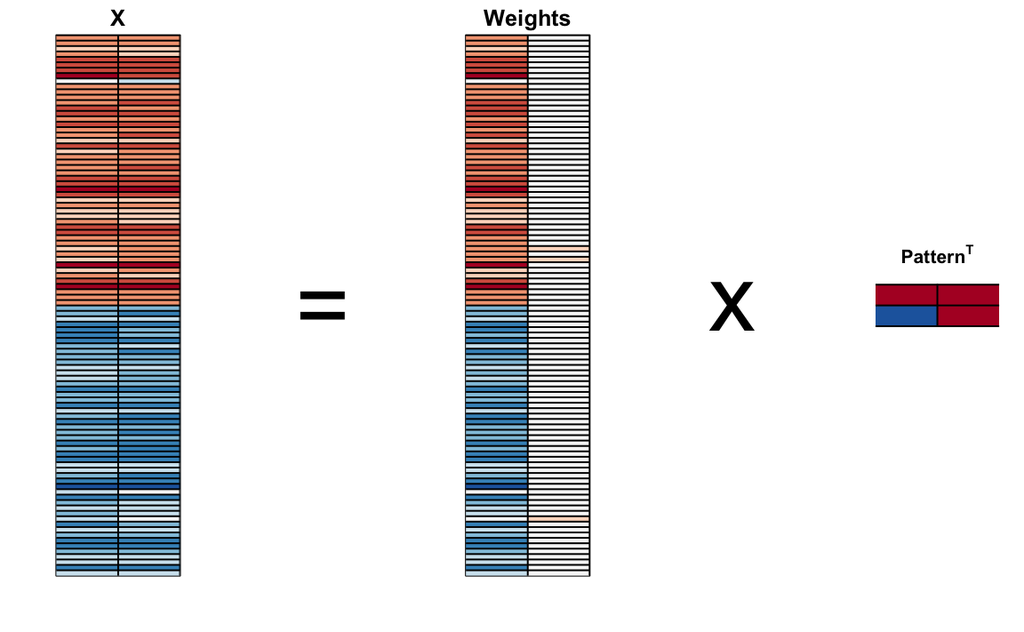

## Principal component analysis

- It turns out that we can find this linear transformation not just for two dimensions but for matrices of any dimension \(p\).
- For a multidimensional matrix with \(X\) with \(p\) columns, we can find a transformation that creates \(Z\) that preserves distance between rows, but with the variance of the columns in decreasing order.
- The second column is the second principal component, the third column is the third principal component, and so on.

## Principal component analysis

- As in our example, if after a certain number of columns, say \(k\), the variances of the columns of \(Z_j\), \(j>k\) are very small, it means these dimensions have little to contribute to the distance and we can approximate distance between any two points with just \(k\) dimensions.
- If \(k\) is much smaller than \(p\), then we can achieve a very efficient summary of our data.

## Iris example

- The iris data is a widely used example in data analysis courses.
- It includes four botanical measurements related to three flower species:

```r
names(iris)
```

```
#> [1] "Sepal.Length" "Sepal.Width"  "Petal.Length" "Petal.Width"  "Species"
```

- If you print `iris$Species` you will see that the data is ordered by the species.
- Let’s compute the distance between each observation.

## Iris example

- You can clearly see the three species with one species very different from the other two:

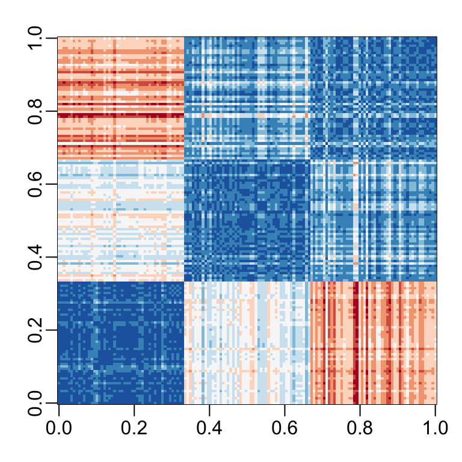

```r
x <- iris[,1:4] |> as.matrix()
d <- dist(x)
image(as.matrix(d), col = rev(RColorBrewer::brewer.pal(9, "RdBu")))
```

## Iris example

- Our predictors here have four dimensions, but three are very correlated:

```r
cor(x)
```

```
#>              Sepal.Length Sepal.Width Petal.Length Petal.Width
#> Sepal.Length        1.000      -0.118        0.872       0.818
#> Sepal.Width        -0.118       1.000       -0.428      -0.366
#> Petal.Length        0.872      -0.428        1.000       0.963
#> Petal.Width         0.818      -0.366        0.963       1.000
```

- If we apply PCA, we should be able to approximate this distance with just two dimensions, compressing the highly correlated dimensions.

## Iris example

- Using the `summary` function we can see the variability explained by each PC:

```r
pca <- prcomp(x)
summary(pca)
```

```
#> Importance of components:
#>                          PC1    PC2    PC3     PC4
#> Standard deviation     2.056 0.4926 0.2797 0.15439
#> Proportion of Variance 0.925 0.0531 0.0171 0.00521
#> Cumulative Proportion  0.925 0.9777 0.9948 1.00000
```

## Iris example

- The first two dimensions account for 97% of the variability.
- Thus we should be able to approximate the distance very well with two dimensions.

## Iris example

- We can visualize the results of PCA:

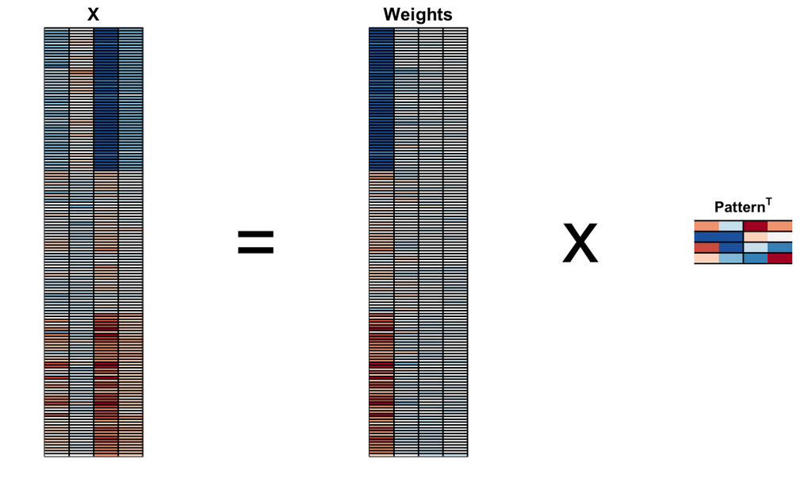

## Iris example

- If you look at the second column of the weights, you notice that it somewhat separates versicolor (red) from virginica (blue).
- We can see this better by plotting the first two PCs with color representing the species:

```r
data.frame(pca$x[,1:2], Species=iris$Species) |>
  ggplot(aes(PC1,PC2, fill = Species))+
  geom_point(cex=3, pch=21) +
  coord_fixed(ratio = 1)
```

## Iris example

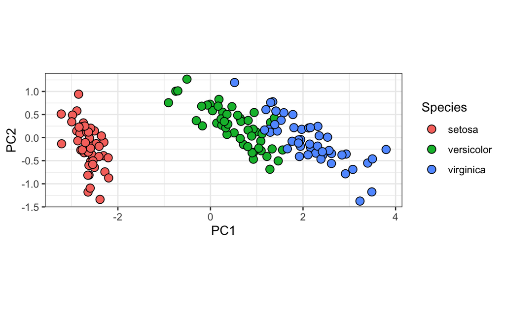

## Iris example

- We see that the first two dimensions preserve the distance:

```r
d_approx <- dist(pca$x[, 1:2])
qplot(d, d_approx) + geom_abline(color="red")
```

## Iris example

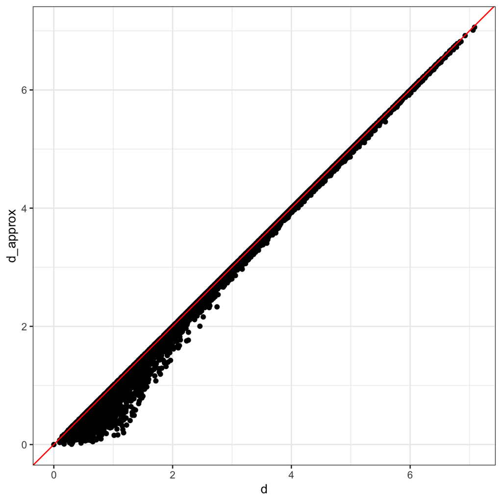

## Iris example

- This example is more realistic than the first artificial example we used, since we showed how we can visualize the data using two dimensions when the data was four-dimensional.

## MNIST example

- The written digits example has 784 features.
- Is there any room for data reduction? Can we create simple machine learning algorithms using fewer features?
- Let’s load the data:

```r
library(dslabs)
if(!exists("mnist")) mnist <- read_mnist()
```

- Because the pixels are so small, we expect pixels close to each other on the grid to be correlated, meaning that dimension reduction should be possible.
- Let’s try PCA and explore the variance of the PCs.

## MNIST example

- This will take a few seconds as it is a rather large matrix.

```r
col_means <- colMeans(mnist$test$images)
pca <- prcomp(mnist$train$images)
```

```r
pc <- 1:ncol(mnist$test$images)
qplot(pc, pca$sdev)
```

## MNIST example

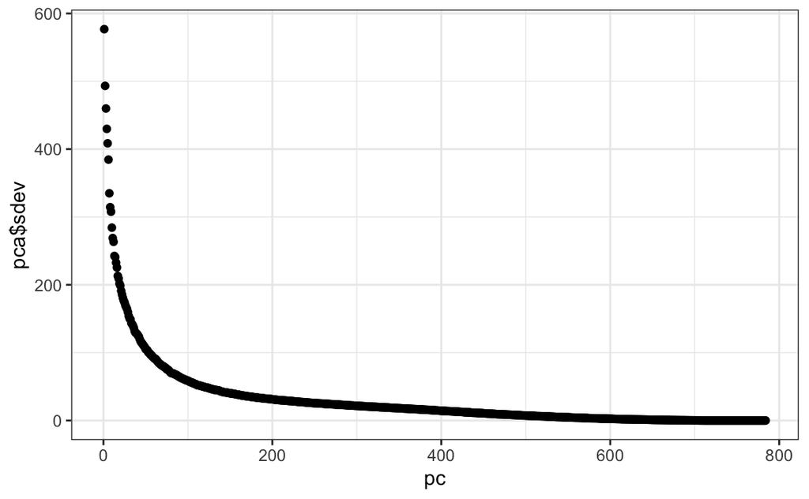

## MNIST example

- We can see that the first few PCs already explain a large percent of the variability:

```r
summary(pca)$importance[,1:5]
```

```
#>                            PC1     PC2      PC3      PC4      PC5
#> Standard deviation     576.823 493.238 459.8993 429.8562 408.5668
#> Proportion of Variance   0.097   0.071   0.0617   0.0539   0.0487
#> Cumulative Proportion    0.097   0.168   0.2297   0.2836   0.3323
```

## MNIST example

- And just by looking at the first two PCs we see information about the class.
- Here is a random sample of 2,000 digits:

```r
data.frame(PC1 = pca$x[,1], PC2 = pca$x[,2],
           label=factor(mnist$train$label)) |>
  sample_n(2000) |>
  ggplot(aes(PC1, PC2, fill=label))+
  geom_point(cex=3, pch=21)
```

## MNIST example

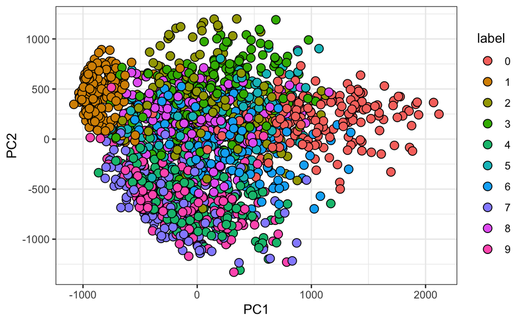

## MNIST example

- We can also *see* the linear combinations on the grid to get an idea of what is getting weighted:

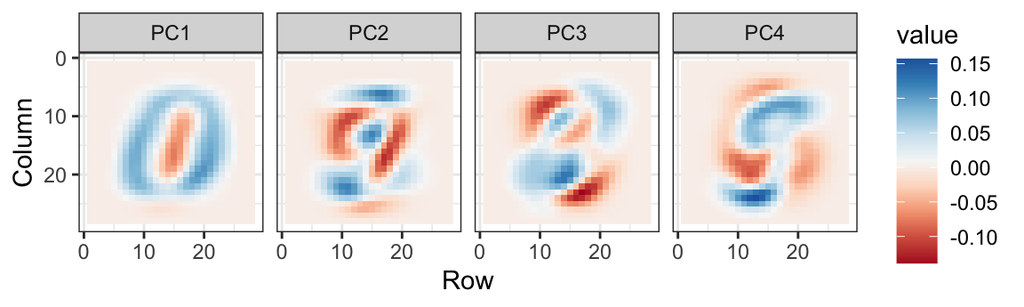

## MNIST example

- The lower variance PCs appear related to unimportant variability in the corners:

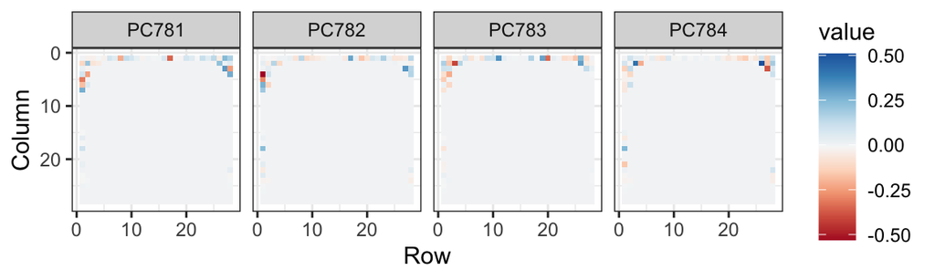

## MNIST example

- Now let’s apply the transformation we learned with the training data to the test data, reduce the dimension and run knn on just a small number of dimensions.
- We try 36 dimensions since this explains about 80% of the data.

## MNIST example

- First fit the model:

```r
library(caret)
k <- 36
x_train <- pca$x[,1:k]
y <- factor(mnist$train$labels)
fit <- knn3(x_train, y)
```

## MNIST example

- Now transform the test set:

```r
x_test <- sweep(mnist$test$images, 2, col_means) %*% pca$rotation
x_test <- x_test[,1:k]
```

## MNIST example

- And we are ready to predict and see how we do:

```r
y_hat <- predict(fit, x_test, type = "class")
confusionMatrix(y_hat, factor(mnist$test$labels))$overall["Accuracy"]
```

```
#> Accuracy
#>    0.975
```

- With just 36 dimensions we get an accuracy well above 0.95.